|  | pclass | survived | name | sex | age | sibsp | parch | ticket | fare | cabin | embarked | boat | body | home.dest |
| --- | --- | --- | --- | --- | --- | --- | --- | --- | --- | --- | --- | --- | --- | --- |
| 0 | 1.0 | 1.0 | Allen, Miss. Elisabeth Walton | female | 29.0000 | 0.0 | 0.0 | 24160 | 211.3375 | B5 | S | 2 | NaN | St Louis, MO |
| 1 | 1.0 | 1.0 | Allison, Master. Hudson Trevor | male | 0.9167 | 1.0 | 2.0 | 113781 | 151.5500 | C22 C26 | S | 11 | NaN | Montreal, PQ / Chesterville, ON |
| 2 | 1.0 | 0.0 | Allison, Miss. Helen Loraine | female | 2.0000 | 1.0 | 2.0 | 113781 | 151.5500 | C22 C26 | S | NaN | NaN | Montreal, PQ / Chesterville, ON |
| 3 | 1.0 | 0.0 | Allison, Mr. Hudson Joshua Creighton | male | 30.0000 | 1.0 | 2.0 | 113781 | 151.5500 | C22 C26 | S | NaN | 135.0 | Montreal, PQ / Chesterville, ON |
| 4 | 1.0 | 0.0 | Allison, Mrs. Hudson J C (Bessie Waldo Daniels) | female | 25.0000 | 1.0 | 2.0 | 113781 | 151.5500 | C22 C26 | S | NaN | NaN | Montreal, PQ / Chesterville, ON |
| ... | ... | ... | ... | ... | ... | ... | ... | ... | ... | ... | ... | ... | ... | ... |
| 1305 | 3.0 | 0.0 | Zabour, Miss. Thamine | female | NaN | 1.0 | 0.0 | 2665 | 14.4542 | NaN | C | NaN | NaN | NaN |
| 1306 | 3.0 | 0.0 | Zakarian, Mr. Mapriededer | male | 26.5000 | 0.0 | 0.0 | 2656 | 7.2250 | NaN | C | NaN | 304.0 | NaN |
| 1307 | 3.0 | 0.0 | Zakarian, Mr. Ortin | male | 27.0000 | 0.0 | 0.0 | 2670 | 7.2250 | NaN | C | NaN | NaN | NaN |
| 1308 | 3.0 | 0.0 | Zimmerman, Mr. Leo | male | 29.0000 | 0.0 | 0.0 | 315082 | 7.8750 | NaN | S | NaN | NaN | NaN |
| 1309 | NaN | NaN | NaN | NaN | NaN | NaN | NaN | NaN | NaN | NaN | NaN | NaN | NaN | NaN |

1310 rows × 14 columns

# Analiza danych dotyczących katastrofy Tytanika

#### Tytanik to brytyjski transatlantyk typu Olympic należący do towarzystwa żeglugowego White Star Line, zbudowany w stoczni Harland and Wolff w Belfaście.

#### Niespełna rok po zwodowaniu, w nocy z 14 na 15 kwietnia 1912 roku, podczas dziewiczego rejsu na trasie Southampton – Cherbourg – Queenstown – Nowy Jork, otarł się o górę lodową i zatonął. Jego katastrofa spowodowała znaczącą nowelizację zasad bezpieczeństwa morskiego, np. wprowadzenie stałego nadzoru gór lodowych na północnym Atlantyku.

#### **Statek posiadał 20 szalup ratunkowych, które mogły pomieścić 1178 osób. Każda szalupa mogła pomieścić około 59 pasażerów**

Link do źródła - Wikipedii

[figure not shown]

### Wstępna analiza danych i ich poprawności

|  | pclass | survived | name | sex | age | sibsp | parch | ticket | fare | cabin | embarked | boat | body | home.dest |
| --- | --- | --- | --- | --- | --- | --- | --- | --- | --- | --- | --- | --- | --- | --- |
| 0 | 1.0 | 1.0 | Allen, Miss. Elisabeth Walton | female | 29.0000 | 0.0 | 0.0 | 24160 | 211.3375 | B5 | S | 2 | NaN | St Louis, MO |
| 1 | 1.0 | 1.0 | Allison, Master. Hudson Trevor | male | 0.9167 | 1.0 | 2.0 | 113781 | 151.5500 | C22 C26 | S | 11 | NaN | Montreal, PQ / Chesterville, ON |
| 2 | 1.0 | 0.0 | Allison, Miss. Helen Loraine | female | 2.0000 | 1.0 | 2.0 | 113781 | 151.5500 | C22 C26 | S | NaN | NaN | Montreal, PQ / Chesterville, ON |
| 3 | 1.0 | 0.0 | Allison, Mr. Hudson Joshua Creighton | male | 30.0000 | 1.0 | 2.0 | 113781 | 151.5500 | C22 C26 | S | NaN | 135.0 | Montreal, PQ / Chesterville, ON |
| 4 | 1.0 | 0.0 | Allison, Mrs. Hudson J C (Bessie Waldo Daniels) | female | 25.0000 | 1.0 | 2.0 | 113781 | 151.5500 | C22 C26 | S | NaN | NaN | Montreal, PQ / Chesterville, ON |

|  | pclass | survived | name | sex | age | sibsp | parch | ticket | fare | cabin | embarked | boat | body | home.dest |
| --- | --- | --- | --- | --- | --- | --- | --- | --- | --- | --- | --- | --- | --- | --- |
| 1305 | 3.0 | 0.0 | Zabour, Miss. Thamine | female | NaN | 1.0 | 0.0 | 2665 | 14.4542 | NaN | C | NaN | NaN | NaN |
| 1306 | 3.0 | 0.0 | Zakarian, Mr. Mapriededer | male | 26.5 | 0.0 | 0.0 | 2656 | 7.2250 | NaN | C | NaN | 304.0 | NaN |
| 1307 | 3.0 | 0.0 | Zakarian, Mr. Ortin | male | 27.0 | 0.0 | 0.0 | 2670 | 7.2250 | NaN | C | NaN | NaN | NaN |
| 1308 | 3.0 | 0.0 | Zimmerman, Mr. Leo | male | 29.0 | 0.0 | 0.0 | 315082 | 7.8750 | NaN | S | NaN | NaN | NaN |
| 1309 | NaN | NaN | NaN | NaN | NaN | NaN | NaN | NaN | NaN | NaN | NaN | NaN | NaN | NaN |

|  | pclass | survived | name | sex | age | sibsp | parch | ticket | fare | cabin | embarked | boat | body | home.dest |
| --- | --- | --- | --- | --- | --- | --- | --- | --- | --- | --- | --- | --- | --- | --- |
| 371 | 2.0 | 1.0 | Christy, Mrs. (Alice Frances) | female | 45.0 | 0.0 | 2.0 | 237789 | 30.0000 | NaN | S | 12 | NaN | London |
| 812 | 3.0 | 0.0 | Fox, Mr. Patrick | male | NaN | 0.0 | 0.0 | 368573 | 7.7500 | NaN | Q | NaN | NaN | Ireland New York, NY |
| 1084 | 3.0 | 0.0 | Olsen, Mr. Karl Siegwart Andreas | male | 42.0 | 0.0 | 1.0 | 4579 | 8.4042 | NaN | S | NaN | NaN | NaN |
| 827 | 3.0 | 0.0 | Goodwin, Master. William Frederick | male | 11.0 | 5.0 | 2.0 | CA 2144 | 46.9000 | NaN | S | NaN | NaN | Wiltshire, England Niagara Falls, NY |
| 1225 | 3.0 | 0.0 | Storey, Mr. Thomas | male | 60.5 | 0.0 | 0.0 | 3701 | NaN | NaN | S | NaN | 261.0 | NaN |

```
<class 'pandas.core.frame.DataFrame'>
RangeIndex: 1310 entries, 0 to 1309
Data columns (total 14 columns):
 #   Column     Non-Null Count  Dtype
---  ------     --------------  -----
 0   pclass     1309 non-null   float64
 1   survived   1309 non-null   float64
 2   name       1309 non-null   object
 3   sex        1309 non-null   object
 4   age        1046 non-null   float64
 5   sibsp      1309 non-null   float64
 6   parch      1309 non-null   float64
 7   ticket     1309 non-null   object
 8   fare       1308 non-null   float64
 9   cabin      295 non-null    object
 10  embarked   1307 non-null   object
 11  boat       486 non-null    object
 12  body       121 non-null    float64
 13  home.dest  745 non-null    object
dtypes: float64(7), object(7)
memory usage: 143.4+ KB
```

|  | pclass | survived | age | sibsp | parch | fare | body |
| --- | --- | --- | --- | --- | --- | --- | --- |
| count | 1309.000000 | 1309.000000 | 1046.000000 | 1309.000000 | 1309.000000 | 1308.000000 | 121.000000 |
| mean | 2.294882 | 0.381971 | 29.881135 | 0.498854 | 0.385027 | 33.295479 | 160.809917 |
| std | 0.837836 | 0.486055 | 14.413500 | 1.041658 | 0.865560 | 51.758668 | 97.696922 |
| min | 1.000000 | 0.000000 | 0.166700 | 0.000000 | 0.000000 | 0.000000 | 1.000000 |
| 25% | 2.000000 | 0.000000 | 21.000000 | 0.000000 | 0.000000 | 7.895800 | 72.000000 |
| 50% | 3.000000 | 0.000000 | 28.000000 | 0.000000 | 0.000000 | 14.454200 | 155.000000 |
| 75% | 3.000000 | 1.000000 | 39.000000 | 1.000000 | 0.000000 | 31.275000 | 256.000000 |
| max | 3.000000 | 1.000000 | 80.000000 | 8.000000 | 9.000000 | 512.329200 | 328.000000 |

```
pclass          1
survived        1
name            1
sex             1
age           264
sibsp           1
parch           1
ticket          1
fare            2
cabin        1015
embarked        3
boat          824
body         1189
home.dest     565
dtype: int64
```

```
pclass          3
survived        2
name         1307
sex             2
age            98
sibsp           7
parch           8
ticket        929
fare          281
cabin         186
embarked        3
boat           27
body          121
home.dest     369
dtype: int64
```

```
Index(['pclass', 'survived', 'name', 'sex', 'age', 'sibsp', 'parch', 'ticket',
       'fare', 'cabin', 'embarked', 'boat', 'body', 'home.dest'],
      dtype='object')
```

### Wnioski:

1. Ostatni rekord jest zepsuty, nie ma żadnych danych. Do usunięcia.
2. Kolumna kabin jest nie przydatna. Zawiera mało danych, dane to str, dużo wartości unikatowcyh. Dane w kolumnie są nie przejrzyste. Do usunięcia.
3. Kolumna ticket w mojej analizie jest nie przydatna. 929 unikatowych wartości a jedynie 3 klasy podrózy. Dodatkowo dane to str.
4. Kolumna fare w mojej analizie jest nie przydatna. Dodatkowo jest dużo unikatowych wartości co może świadczyć że dane sa zepsute
5. W kolumnie 'age' nie brakuje tak dużo danych. Wypełnimy je średnią arytmetyczną dla całej kolumny.
6. Dla przejrzystości zmienimy nazwy kolumn na Polskie, a nazwisko dam na pierwszej pozycji.

#### Dane przeanalizujemy pod kątem przeżywalności pasażerów według płci oraz klasy podróży. Sprawdzimy również ilu dodatkowych pasażerów mogło zostać uratowanych jeśli szalupy ratunkowy byłyby wypełnoione całkowice

|  | nazwisko | klasa | przeżycie | płeć | wiek | port | szalupa | ciało | cel |
| --- | --- | --- | --- | --- | --- | --- | --- | --- | --- |
| 63 | Chaffee, Mrs. Herbert Fuller (Carrie Constance... | 1 | True | kobieta | 47.0 | S | 4 | NaN | Amenia, ND |
| 406 | Faunthorpe, Mr. Harry | 2 | False | mężczyzna | 40.0 | S | NaN | 286.0 | England / Philadelphia, PA |
| 912 | Karaic, Mr. Milan | 3 | False | mężczyzna | 30.0 | S | NaN | NaN | NaN |
| 943 | Laitinen, Miss. Kristina Sofia | 3 | False | kobieta | 37.0 | S | NaN | NaN | NaN |
| 939 | Klasen, Mrs. (Hulda Kristina Eugenia Lofqvist) | 3 | False | kobieta | 36.0 | S | NaN | NaN | NaN |

```
nazwisko        0
klasa           0
przeżycie       0
płeć            0
wiek            0
port            2
szalupa       823
ciało        1188
cel           564
dtype: int64
```

```
nazwisko     1307
klasa           3
przeżycie       2
płeć            2
wiek           99
port            3
szalupa        27
ciało         121
cel           369
dtype: int64
```

## Analiza przeżywalności pasażerów pod kątem płci i klasy podróży

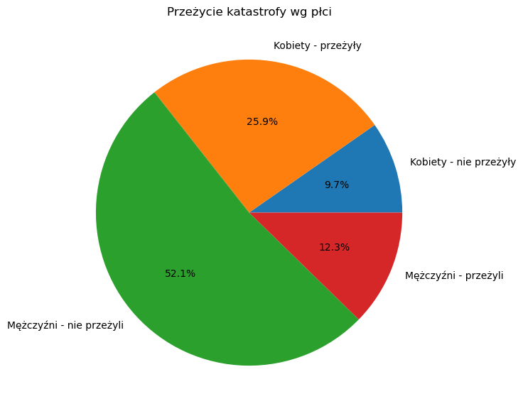

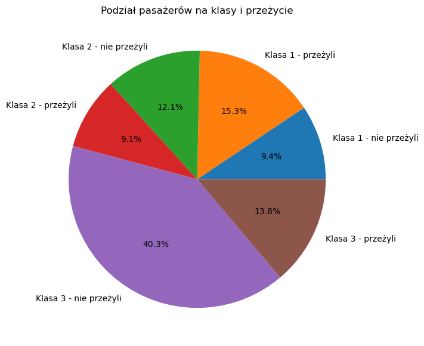

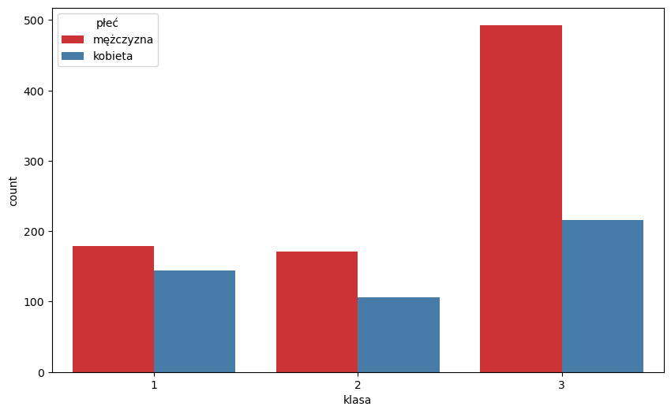

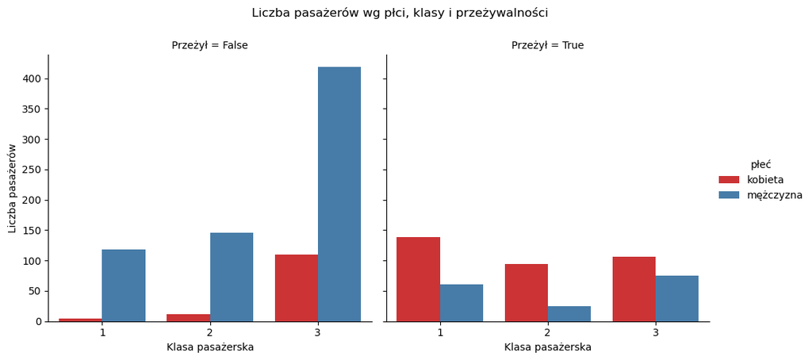

|  | index | liczba pasażerów |
| --- | --- | --- |
| 0 | mężczyzna | 843 |
| 1 | kobieta | 466 |

|  | płeć | udział [%] |
| --- | --- | --- |
| 0 | mężczyzna | 64.4 |
| 1 | kobieta | 35.6 |

```
False    809
True     500
Name: przeżycie, dtype: int64
```

|  | płeć | klasa | przeżycie | liczba pasażerów |
| --- | --- | --- | --- | --- |
| 0 | mężczyzna | 3 | False | 418 |
| 1 | mężczyzna | 2 | False | 146 |
| 2 | kobieta | 1 | True | 139 |
| 3 | mężczyzna | 1 | False | 118 |
| 4 | kobieta | 3 | False | 110 |
| 5 | kobieta | 3 | True | 106 |
| 6 | kobieta | 2 | True | 94 |
| 7 | mężczyzna | 3 | True | 75 |
| 8 | mężczyzna | 1 | True | 61 |
| 9 | mężczyzna | 2 | True | 25 |
| 10 | kobieta | 2 | False | 12 |
| 11 | kobieta | 1 | False | 5 |

```
inne                               781
New York, NY                        64
London                              14
Montreal, PQ                        10
Cornwall / Akron, OH                 9
                                  ...
Skara, Sweden / Rockford, IL         2
St Ives, Cornwall / Calumet, MI      2
London / Paris                       2
England                              2
Mamaroneck, NY                       2
Name: cel, Length: 153, dtype: int64
```

## Analiza wypełnienia szalup ratunkowych

##### Analiza ta ma celu sprawdzić ile dodatkowo osób mogłoby przeżyć, jeżeli ewakuacja zostałaby przeprowadzone w lepszy sposób.

```
13         39
C          38
15         37
14         33
4          31
10         29
5          27
3          26
9          25
11         25
16         23
8          23
7          23
D          20
6          20
12         19
2          13
A          11
B           9
1           5
5 7         2
C D         2
13 15       2
5 9         1
8 10        1
13 15 B     1
15 16       1
Name: szalupa, dtype: int64
```

|  | index | ilość pasażerów |
| --- | --- | --- |
| 0 | brak szalupy | 823 |
| 1 | 15 | 39 |
| 2 | 13 | 39 |
| 3 | C | 38 |
| 4 | 14 | 33 |
| 5 | 4 | 31 |
| 6 | 10 | 30 |
| 7 | 5 | 27 |
| 8 | 3 | 26 |
| 9 | 9 | 26 |
| 10 | 7 | 25 |
| 11 | 11 | 25 |
| 12 | 16 | 24 |
| 13 | 8 | 23 |
| 14 | D | 22 |
| 15 | 6 | 20 |
| 16 | 12 | 19 |
| 17 | 2 | 13 |
| 18 | A | 11 |
| 19 | B | 10 |
| 20 | 1 | 5 |

```
21
```

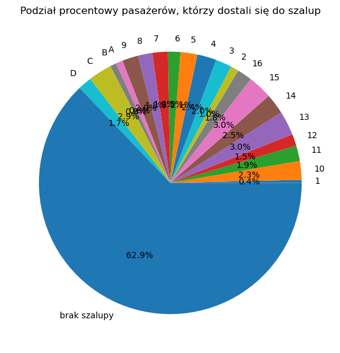

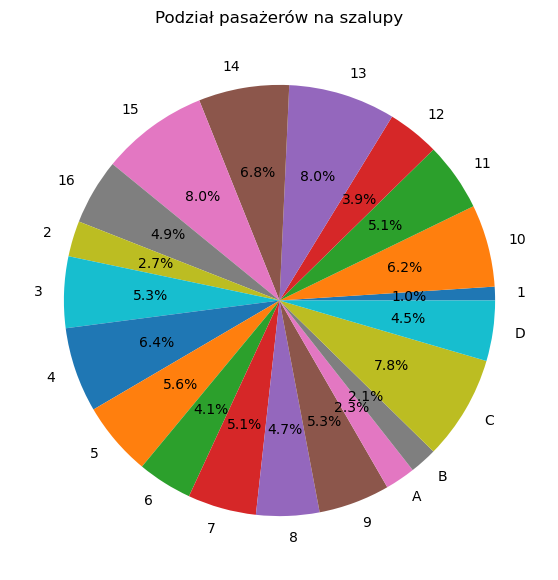

|  | szalupa | ilość pasażerów | maksymalna pojemność | wolne miejsca | procent wolnych miejsc |
| --- | --- | --- | --- | --- | --- |
| 0 | 15 | 39 | 59 | 20 | 33.898305 |
| 1 | 13 | 39 | 59 | 20 | 33.898305 |
| 2 | C | 38 | 59 | 21 | 35.593220 |
| 3 | 14 | 33 | 59 | 26 | 44.067797 |
| 4 | 4 | 31 | 59 | 28 | 47.457627 |
| 5 | 10 | 30 | 59 | 29 | 49.152542 |
| 6 | 5 | 27 | 59 | 32 | 54.237288 |
| 7 | 3 | 26 | 59 | 33 | 55.932203 |
| 8 | 9 | 26 | 59 | 33 | 55.932203 |
| 9 | 11 | 25 | 59 | 34 | 57.627119 |
| 10 | 7 | 25 | 59 | 34 | 57.627119 |
| 11 | 16 | 24 | 59 | 35 | 59.322034 |
| 12 | 8 | 23 | 59 | 36 | 61.016949 |
| 13 | D | 22 | 59 | 37 | 62.711864 |
| 14 | 6 | 20 | 59 | 39 | 66.101695 |
| 15 | 12 | 19 | 59 | 40 | 67.796610 |
| 16 | 2 | 13 | 59 | 46 | 77.966102 |
| 17 | A | 11 | 59 | 48 | 81.355932 |
| 18 | B | 10 | 59 | 49 | 83.050847 |
| 19 | 1 | 5 | 59 | 54 | 91.525424 |

|  | ilość pasażerów | maksymalna pojemność | wolne miejsca | procent wolnych miejsc |
| --- | --- | --- | --- | --- |
| count | 20.000000 | 20.0 | 20.000000 | 20.000000 |
| mean | 24.300000 | 59.0 | 34.700000 | 58.813559 |
| std | 9.520615 | 0.0 | 9.520615 | 16.136635 |
| min | 5.000000 | 59.0 | 20.000000 | 33.898305 |
| 25% | 19.750000 | 59.0 | 28.750000 | 48.728814 |
| 50% | 25.000000 | 59.0 | 34.000000 | 57.627119 |
| 75% | 30.250000 | 59.0 | 39.250000 | 66.525424 |
| max | 39.000000 | 59.0 | 54.000000 | 91.525424 |

[output not shown]

## Wnioki

#### W badanej próbce zginęło 809 pasażerów a pozostało 694 wolnych miejsc na szalupach ratunkowych. Czyli prawie wszyscy mogli przeżyć. Najwyraźnij zawiodło:

1. Przepisy bezpieczeństwo,.
2. źle wyznaczone lub całkowity brak dróg ewakuacyjnych.
3. Przeszkolenie BHP oraz planu ewakuacji przez załogę oraz pasażerów.

#### Po katastrofie wprowadzono wiele nowych międzynarodowych przepisów dotyczących bezpieczeństwa na morzu. Najważniejszy był Konwencja SOLAS (Safety of Life at Sea) z 1914 roku, która obowiązuje (z aktualizacjami) do dziś.

#### Po tragedii powstała organizacja Międzynarodowa Służba Patrolowa Lodów (International Ice Patrol), która do dziś monitoruje obszary Atlantyku, gdzie występują góry lodowe.

#### Projektanci i stocznie zaczęli stosować, pełne, wodoszczelne grodzie zamiast tylko częściowych oraz wprowadzono większą ilość środków ratunkowych.